TRexSelector R package guide

# Memory mapping: disk-backed designs

# A design larger than the memory

A memory-mapped matrix lives in a file on disk, and the operating system pages the parts in use into memory. The C++ backend binds such a file exactly as it binds an R matrix, so every selector, every T-solver, the scalers, the low-memory regression engines and the clustering accept one. That is how a sparse regression problem with five million variables was solved on a laptop [1]. The file holds the matrix as raw doubles in column-major order, the layout of R and Eigen, without a header.

The file is mapped through Boost.Interprocess [2], the library of the Boost C++ Libraries for memory-mapped files and shared memory. In R, the bigmemory package [3] established disk-backed matrices for statistics, and the first Big T-Rex [1] was written for its `big.matrix` objects. The library binds any buffer instead, mapped or not, so the selectors never see where the design lives, as Figure 1 shows.

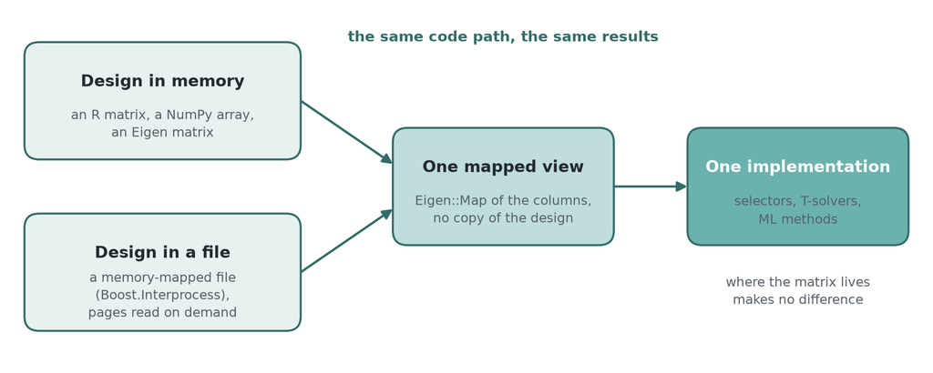

Figure 1: A design in memory and a design in a file reach the same implementation through one mapped view.

# Creating and opening a mapped matrix

`mem_matrix_from()` writes an R matrix to a file and returns a handle, `mem_matrix()` opens an existing file with its dimensions and the access mode.

```r
set.seed(5)
n <- 100
p <- 200
X <- matrix(rnorm(n * p), n, p)
path <- tempfile(fileext = ".bin")
mm <- mem_matrix_from(X, path)
class(mm)
```

```
#> [1] "MemoryMappedMatrix" "mmap_matrix"        "externalptr"
```

```r
dim(mm)
```

```
#> [1] 100 200
```

```r
file.size(path) == 8 * n * p
```

```
#> [1] TRUE
```

The handle supports the matrix operations one needs to inspect and to edit the file. Reading a block copies it into R memory, the backend never does.

```r
round(mm[1:2, 1:3], 3)
```

```
#>        [,1]   [,2]   [,3]
#> [1,] -0.841 -1.995 -0.114
#> [2,]  1.384  1.135 -0.295
```

```r
identical(mm[1:2, 1:3], X[1:2, 1:3])
```

```
#> [1] TRUE
```

```r
mm[1, 1] <- 42
mm[1, 1]
```

```
#> [1] 42
```

```r
mm[1, 1] <- X[1, 1]
max(abs(as.matrix(mm) - X))
```

```
#> [1] 0
```

```r
ro <- mem_matrix(path, rows = n, cols = p, mode = "readonly")
tryCatch(ro[1, 1] <- 0, error = function(e) cat("error:", conditionMessage(e), "\n"))
```

```
#> error: Cannot write to a read-only mmap_matrix.
```

# Streaming a design into the file

A design that does not fit in memory is written column by column. The file is raw doubles in column-major order, so `writeBin()` of one column after another produces it.

```r
path2 <- tempfile(fileext = ".bin")
con <- file(path2, open = "wb")
for (j in seq_len(p)) {
  set.seed(1000 + j)
  writeBin(rnorm(n), con)
}
close(con)
big <- mem_matrix(path2, rows = n, cols = p, mode = "readwrite")
set.seed(1000 + 3)
max(abs(as.numeric(big[, 3]) - rnorm(n)))
```

```
#> [1] 0
```

# Selectors on a mapped design

The selectors take the handle where they take `X`. The file must be open in `"readwrite"` mode, because the selector centers and scales the design in place and restores it when `select()` returns (the page on working without data copies has the contract).

```r
beta <- c(rep(1.5, 4), rep(0, p - 4))
y <- as.numeric(X %*% beta + rnorm(n))
sel_mem <- TRexSelector$new(X, y, tFDR = 0.1, seed = 3, verbose = FALSE,
                            control = trex_control(K = 10))
sel_mem$select()
sel_map <- TRexSelector$new(mm, y, tFDR = 0.1, seed = 3, verbose = FALSE,
                            control = trex_control(K = 10))
sel_map$select()
identical(sel_mem$selected_indices, sel_map$selected_indices)
```

```
#> [1] TRUE
```

```r
max(abs(as.matrix(mm) - X))      # the file holds the original values again
```

```
#> [1] 0
```

The same holds for `TRexDASelector`, `TRexGVSSelector`, `TRexScreeningSelector`, `TRexBiobankScreeningSelector`, `TRexSPCASelector` and `TRexTikhonovSelector`. `trex_control(use_memory_mapping = TRUE)` additionally keeps the dummy matrices of the random experiments in mapped files, for the case where $K \cdot L \cdot p$ dummy columns do not fit either.

# T-solvers and ML methods

A T-solver binds the mapped `X` as it binds a matrix, the scalers transform the file in place, the low-memory engines of the regressions read it in place, and the clustering accepts it as `data`.

```r
D <- matrix(rnorm(n * p), n, p)
s <- TLARS_Solver$new(mm, D, y)
s$execute_step(T_stop = 2)
s$get_active_predictor_indices()
```

```
#> [1]  2  4  3  1 30 14
```

```r
s$restore()
z <- MLZScoreScaler$new()
invisible(z$fit_transform_inplace(mm))
round(mean(mm[, 1]), 12)
```

```
#> [1] 0
```

```r
invisible(z$inverse_transform_inplace(mm))
en <- MLElasticNet$new(low_memory = TRUE)
en$fit(mm, y, alpha = 1, n_lambda = 20)
dim(en$get_coef())
```

```
#> [1] 200  20
```

# When it pays

A mapped design pays when the design does not fit into memory, when several solvers share one design and the working set should be loaded once, and when a design is produced by a streaming process and read afterwards. For a design that fits comfortably in memory an R matrix is faster, since no paging happens. Mapped files are never read into R’s heap by the backend, so the memory footprint of a run is the backend’s working data, see `get_memory_bytes()` on the T-solvers.

# Examples

The [TRexSelector_Examples](https://github.com/trexselector/TRexSelector_Examples/tree/main) repository holds runnable demos and Monte Carlo studies of memory-mapped designs, with their results and a README per demo, in [R](https://github.com/trexselector/TRexSelector_Examples/tree/main/R/memory_mapping/demo_memory_mapping), [Python](https://github.com/trexselector/TRexSelector_Examples/tree/main/Python/memory_mapping/demo_memory_mapping) and [C++](https://github.com/trexselector/TRexSelector_Examples/tree/main/cpp/memory_mapping/demo_memory_mapping).

# Bibliography

[1]

F. Scheidt, J. Machkour, and M. Muma, “Solving FDR-controlled sparse regression problems with five million variables on a laptop,” in *Proc. IEEE 9th int. Workshop comput. Adv. Multi-sensor adapt. Process. (CAMSAP)*, 2023, pp. 116–120. doi: 10.1109/CAMSAP58249.2023.10403478.

[2]

I. Gaztañaga, “Boost.Interprocess.” 2008. Available: https://www.boost.org/libs/interprocess

[3]

M. J. Kane, J. W. Emerson, and S. Weston, “Scalable strategies for computing with massive data,” *J. Stat. Softw.*, vol. 55, no. 14, pp. 1–19, 2013, doi: 10.18637/jss.v055.i14.